# Developing Data Products shinyapp project Over view

Wayne Hockensmith

April 16, 2017

# Overview

The shiny application that I built  
[MPG vs Number of cylinders, Gears, Transmission Type, and Engine Displacement](https://whockensmith.shinyapps.io/developing_data_products_shinyapp_project/)  
allows the user to compare the MPG of cars to the cars number of cylinders, gears, the type of transmission and the car’s engine displacement.

The application contains a Bar and Whiskers plot that allows the user to do two dimensional comparisons between MPG and number of cylinders or number of gears or transmission type. The user can also switch to a Coplot that will add a third dimension of comparison by adding engine displacement.

The data is from the mtcars table with in R-Studio. It was extracted from the 1974 Motor Trend US magazine, and comprises fuel consumption and 10 aspects of automobile design and performance for 32 automobiles (1973-74 models).

# Application Preview

Opening view  
Box and Whisker .  
.  
.  
.  
.  
.  
Coplot

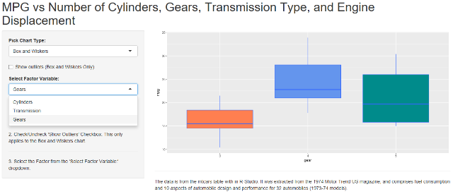

_____________________________________________________________________

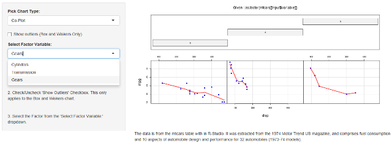

# Using the Application

On the top left choose the type of graph with the “Pick Chart Type:” dropdown.  
Below that is a check box to select or hide outliers. This in only for the Box and Whiskers charts.  
Next is a dropdown box for selecting the Factor Variable. This is conveniently called the “Select Factor Variable:”. The choices are: Cylinders, Transmission, and Gears.

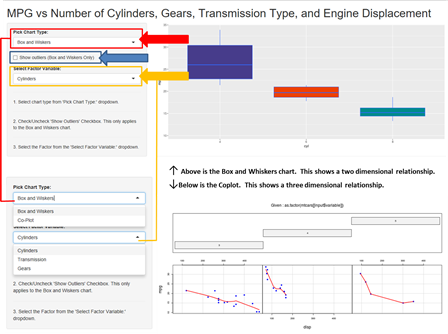

The application is easy to opperate. Reading the graphs are fairly straight forward.

# Reproducing The Application

The application was build using Rstudio (version 3.3.1 (2016-06-21)) and knited to Rstudio’s shinyapp.io cloud server.

The server.R and ui.R files can be found in folder [“/Dev_data_products”](https://github.com/Whockensmith/Developing_Data_Products/tree/master/Dev_data_products).

The .dcf file is in the [“/rsconnect”](https://github.com/Whockensmith/Developing_Data_Products/blob/master/Dev_data_products/rsconnect/shinyapps.io/whockensmith/developing_data_products_shinyapp_project.dcf) subfolder.

I have two slide shows, one knitted with [slidy](http://rpubs.com/Whockensmith/268688) and on knitted with [ioslides](http://rpubs.com/Whockensmith/268689). You are currently viewing the slidy version. I did both versions because each one has its pros and cons and the user can use which ever version he/she prefers. The raw html slide shows are located in the root directory [“/Developing_Data_Products”](https://github.com/Whockensmith/Developing_Data_Products).

The [shinyapp](https://whockensmith.shinyapps.io/developing_data_products_shinyapp_project/) is located on the shinyoi server at (“https://whockensmith.shinyapps.io/developing_data_products_shinyapp_project/”)